# Auction Targeting

Research, metric design, and 2026 Gusteroids guidance

Published

March 25, 2026

# Research Report

## What We Did

Built a real-time auction targeting tool for the Moonlight Graham league’s annual draft. The tool combines player valuations with live auction state to produce a continuously updated **Targeting Score** and **Bid Ceiling** for every available player.

The core question: given *your* roster, *your* budget, and the players still available, who should you target next and how much should you pay?

We designed a three-component metric framework, implemented it as a Streamlit application, and calibrated it to the Gusteroids’ 2026 roster and projected standings.

## What We Learned

### Categories are the unit of value

Standard SGP dollar values assume a generic team drafting from scratch. In a keeper league auction, your actual value of a player depends on your current roster composition — a player who pushes you from 7th to 5th in SB is worth more to a team weak in steals than to a team already ranked 2nd.

The breakthrough framing was thinking in terms of **marginal standings points** rather than marginal SGP. SGP is a means to an end; the end is standings points. By estimating the full 10-team standings matrix and measuring how a player moves your position within it, we get a number with direct real-world meaning: *this player is worth approximately X more to me than to the average team.*

This is the **Personal Value Premium (PVP)** — the dollar premium a player adds to the Gusteroids specifically, beyond their generic market value.

### Scarcity is opportunity cost

Scarcity isn’t about how many players exist at a position. It’s about whether you can get comparable quality later if you pass now. A player is scarce when the gap between their value and the next comparable player’s value is large.

Two-dimensional bucketing — dollar tier (Elite, Premium, Solid, Filler, Min) crossed with category profile (Power, Speed, Average, Balanced, Closer, Starter) — captures both quality and functional role. The **Scarcity Premium (SP)** is the dollar gap between a player and the mean of the top 3 remaining comparables. When many comparables exist, SP collapses to zero. When a player is the last or one of few in their quality+role bucket, SP spikes.

### MI as gate, not weight

Market inefficiency is important information but not symmetric with PVP and SP. You shouldn’t target a player just because they’re undervalued if they don’t fill a need; and you shouldn’t skip a player just because they’re overvalued if the fit and scarcity premium justifies paying more than market.

**Market Inefficiency (MI)** = production value (single-pool) minus auction value (split-pool). Positive means the market underprices the player; negative means overpriced. In the composite Targeting Score, MI contributes on the same 0–10 scale as PVP and SP, so undervaluation does get credit — but the bid ceiling formula keeps MI as a gate: your ceiling is market price plus the premiums you should actually pay for fit and scarcity.

### Validation decision

Proper validation of scarcity requires auction order data — who was available when, at what prices. Public AL-only leagues (LABR, TOUT Wars) come closest structurally but differ enough in team count and rules that their data would miscalibrate rather than calibrate the model.

**Decision:** Record tonight’s auction comprehensively (nomination order, all bids, final prices) and use that as the first ground-truth dataset. Post-season, backtest using final standings against TS at auction time.

## Applicability

- **PVP** is directly reusable each season with updated projections and keeper rosters
- **SP** tier breakpoints may need annual tuning as the player pool quality distribution shifts
- **The team competition model** improves over time as you accumulate more keeper data
- **Dollars-per-standings-point** conversion ($6.55/pt) can be empirically calibrated after each season

# Metric Design

## Three Components

The targeting score is built from three components, each rescaled to a common 0–10 range so that no single component dominates the composite.

| Component | Full Name | What It Measures | Raw Units | Scale |
| --- | --- | --- | --- | --- |
| PVP | Personal Value Premium | Roster fit: standings points this player adds to *your* team | MSP × $6.55/pt | 0–10 |
| SP | Scarcity Premium | Opportunity cost: gap between this player and next comparable | Dollar gap | 0–10 |
| MI | Market Inefficiency | Market pricing: production value minus auction market price | Dollar diff | 0–10 |

### Composite Targeting Score

$$TS = \frac{PVP_{0\text{-}10} + SP_{0\text{-}10} + MI_{0\text{-}10}}{3}$$

Each component is min-max rescaled to 0–10 across the pool of available free agents. The composite TS is their average, also on a 0–10 scale. Higher TS = target harder. Equal weighting is the baseline — after tonight’s auction, the recorded data can be used to empirically calibrate weights.

### Bid Ceiling

$$\text{Bid Ceiling} = \min\!\bigl(\text{Auc\$} + 0.5 \times \max(0, PVP_{\$}) + 0.5 \times \max(0, SP_{\$}),\;\$75,\;\text{budget cap}\bigr)$$

The bid ceiling uses the **raw dollar** PVP and SP (not the rescaled 0–10 values), dampened by 50% to prevent unrealistically aggressive ceilings — raw PVP alone can exceed a player’s entire production value. Capped at the league’s $75 maximum salary and the budget constraint. It answers: *what is the absolute most I should pay for this player?*

# 2026 Gusteroids Situation

## Keeper Roster

Gusteroids 2026 Keepers

11 active + 4 farm — $88 committed, $272 remaining

| Pos | Player | Salary | Year | Status |
| --- | --- | --- | --- | --- |
| Hitters |  |  |  |  |
| 1B | Miguel Vargas | $4 | b | act |
| 2B | Jackson Holliday | $10 | cr | act |
| C | Edgar Quero | $7 | br | act |
| C | Ben Rice | $3 | b | act |
| CI | Tyler Soderstrom | $10 | b | act |
| MI | Luke Keaschall | $7 | br | act |
| OF | Evan Carter | $10 | b | act |
| OF | Roman Anthony | $7 | br | act |
| UT | Jac Caglianone | $7 | br | act |
| Pitchers |  |  |  |  |
| P | Matt Brash | $1 | b | act |
| P | Garrett Whitlock | $2 | b | act |
| Farm / Reserve |  |  |  |  |
| C | Thayron Liranzo | $5 | r | min |
| OF | Emmanuel Rodriguez | $5 | r | min |
| P | Shunpeita Yamashita | $5 | r | min |
| SS | Sebastian Walcott | $5 | r | min |

## Budget Position

| Total budget | $360 |
| --- | --- |
| Keeper salary | $88 |
| Budget left | $272 |
| Open hitter spots | 6 |
| Open pitcher spots | 9 |
| Effective budget | $257 ($272 − 15 × $1 reserve) |

## Category Ranks (Projected)

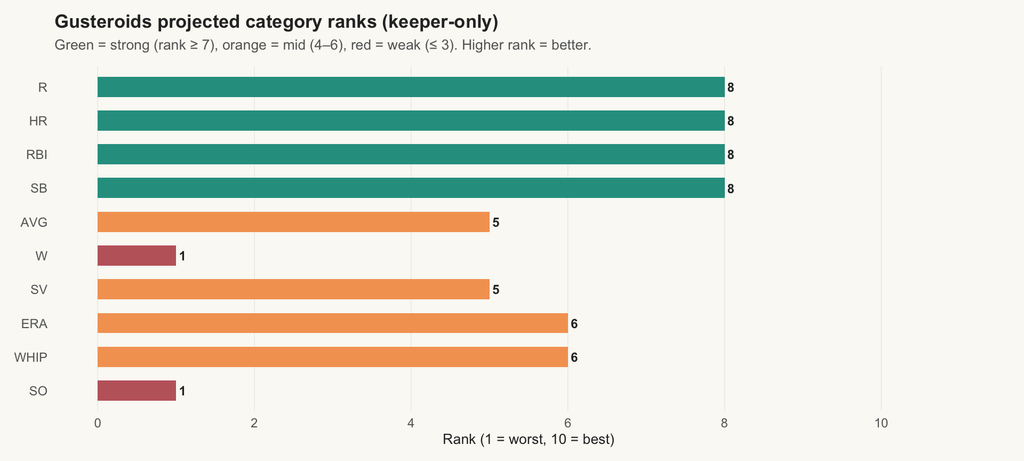

## Free Agent Pool

Free Agent Pool by Tier

592 free agents total (470 Sub-tier excluded from table)

| Tier | Hitters | Pitchers | Total |
| --- | --- | --- | --- |
| Elite | 8 | 12 | 20 |
| Premium | 11 | 9 | 20 |
| Solid | 15 | 16 | 31 |
| Filler | 13 | 11 | 24 |
| Min | 17 | 10 | 27 |

# Strategic Guidance

## Targeting Priorities

Based on the Gusteroids’ category deficits and the available player pool:

- **Closers** (SV rank is only 5th — room to gain standings points here)
- **ERA/WHIP stabilizers** (rank 6th in both — high-floor arms protect your rate stats as you accumulate IP from less reliable starters)

**3. Scarcity matters most at the extremes.** The SP component activates when a player is the last (or one of very few) in their tier+profile bucket. Watch for:

- Elite/Premium speed profiles (few pure SB contributors at top tiers)
- Premium closers (only a handful of reliable saves sources)

## Budget Strategy

With $272 in budget and 15 open spots:

- **Effective budget** is $257 (reserving $1 per open spot)
- **Budget cap** per player is $258 (can spend down to $1 for the last spot)
- **Target allocation**: concentrate spending on 4–6 impact hitters ($20–45 range), fill pitching cheaply ($1–8 range), and leave room for 1–2 mid-range closers ($10–20)

The roster is young and cheap at keeper positions. The auction budget should be deployed aggressively on short-term hitting production — these players won’t be kept, so extract maximum 2026 value.

## How to Use the App

Run the live tool during the auction:

```bash
streamlit run auction/app.py
```

**During the auction:**

1. As each player is sold, log the result in the top bar (player, price, winning team)
2. The table automatically re-sorts by Targeting Score after each logged result
3. Use the **position filter** to focus on positions you need to fill
4. Use the **tier filter** (default: Solid & above) to focus on impact players
5. The **Bid $** column is your hard ceiling — never exceed it

**Reading the table:**

| Column | Range | Meaning |
| --- | --- | --- |
| PVP | 0–10 | Roster fit. Higher = fills your weak categories |
| SP | 0–10 | Scarcity. Higher = fewer comparable alternatives remain |
| MI | 0–10 | Market value. Higher = more undervalued by market |
| TS | 0–10 | Composite. Average of PVP, SP, MI. Primary sort |
| Bid $ | $1–75 | Hard ceiling in raw dollars |

**Key signals:**

- **High PVP + High SP**: Must-target. This player fills a need and you can’t replace them later.
- **High PVP + Low SP**: Target but don’t overpay. Comparable options exist if the price gets too high.
- **Low PVP + High MI**: Bargain available but doesn’t help your roster. Let someone else grab the deal.
- **High TS overall**: This is your priority list. Trust the composite.